# Solution Set 2

## COM 506 P ANALYTICS & SYSTEMS OF BIGT DATA PRACTICE – PROBLEM SET II

```python
import matplotlib.pyplot as plt
import numpy as np
import seaborn as sbn
# for funnel plot
import plotly.express as px
#  for
import math
```

1. On New Year’s Eve, Tina walked into a random shop and surprised to see a huge crowd there. She is interested to find what kind of products they sell the most, for which she needs the age distribution of customers. Help her to find out the same using histogram. The age details of the customers are given below

7, 9, 27, 28, 55, 45, 34, 65, 54, 67, 34, 23, 24, 66, 53, 45, 44, 88, 22, 33, 55, 35, 33, 37, 47, 41,31, 30, 29, 12.

Identify the type of histogram (eg. Bimodal, Multimodal, Skewed..etc). Use different bin sizes.

```python
data = [7, 9, 27, 28, 55, 45, 34, 65, 54, 67, 34, 23, 24, 66, 53, 45, 44, 88, 22, 33, 55, 35, 33, 37, 47, 41,31, 30, 29, 12]
len(data)
```

```
30
```

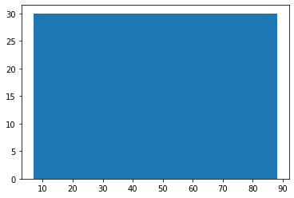

```python
#  the graph below is uniform histogram
plt.hist(data, bins= 1)
```

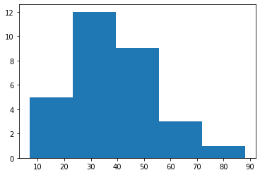

```python
#  the graph below is normal histogram
plt.hist(data, bins= 5)
```

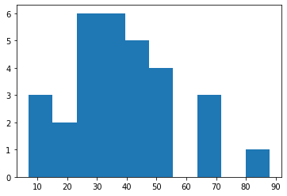

```python
# This graph is normal histogram
plt.hist(data)
```

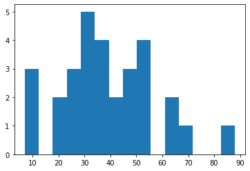

```python
# This graph here is multimodal histogram
plt.hist(data, bins= 15)
```

Variations with number of bins

[output not shown]

## Conclusion

As the number of data points reach the number of data points the conclusions drawn from the graph changes, it is like drilling up. The number of bins hence are needed to be decided on the scale we work in.

1. A Coach tracked the number of points that each of his 30 players on the team had in one game. The points scored by each player is given below. Visualize the data using ordered stem-leaf plot and also detect the outliers and shape of the distribution.

22, 21, 24, 19, 27, 28, 24, 25, 29, 28, 26, 31, 28, 27, 22, 39, 20, 10, 26, 24, 27, 28, 26, 28, 18, 32, 29, 25, 31, 27.

```python
data = [
        22, 21, 24, 19, 27,
        28, 24, 25, 29, 28,
        26, 31, 28, 27, 22,
        39, 20, 10, 26, 24,
        27, 28, 26, 28, 18,
        32, 29, 25, 31, 2
       ]
```

```python
stem_leaf = {}
for i in data:
    if (i // 10) in stem_leaf:
        stem_leaf[i // 10].append(i % 10)
    else:
        stem_leaf[i // 10] = list([i % 10])
stem_leaf
```

```
{2: [2, 1, 4, 7, 8, 4, 5, 9, 8, 6, 8, 7, 2, 0, 6, 4, 7, 8, 6, 8, 9, 5],
 1: [9, 0, 8],
 3: [1, 9, 2, 1],
 0: [2]}
```

```
<StemContainer object of 3 artists>
```

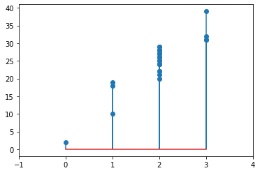

```python
# separating the stem parts
stems = [x // 10 for x in data]
plt.xlim(-1, 4)
plt.stem(stems, data, use_line_collection=True)
```

1. For a sample space of 15 people, a statistician wanted to know the consumption of water and other beverages. He collected their average consumption of water and beverages for 30 days (in litres). Help him to visualize the data using density plot, rug plot and identify the mean, median, mode and skewness of the data from the plot.

| WATER | 3.2 | 3.5 | 3.6 | 2.5 | 2.8 | 5.9 | 2.9 | 3.9 | 4.9 | 6.9 | 7.9 | 8.0 | 3.3 | 6.6 | 4.4 |
| --- | --- | --- | --- | --- | --- | --- | --- | --- | --- | --- | --- | --- | --- | --- | --- |
| BEVERAGES | 2.2 | 2.5 | 2.6 | 1.5 | 3.8 | 1.9 | 0.9 | 3.9 | 4.9 | 6.9 | 0.1 | 8.0 | 0.3 | 2.6 | 1.4 |

```python
water_data = [3.2, 3.5, 3.6, 2.5, 2.8, 5.9, 2.9, 3.9, 4.9, 6.9, 7.9, 8.0, 3.3, 6.6, 4.4]
bev_data = [2.2, 2.5, 2.6, 1.5, 3.8, 1.9, 0.9, 3.9, 4.9, 6.9, 0.1, 8.0, 0.3, 2.6, 1.4]
```

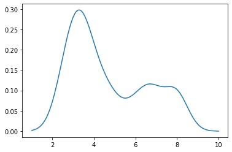

```python
from scipy.stats import gaussian_kde
density = gaussian_kde(water_data)
xs = np.linspace(1,10,200)
density.covariance_factor = lambda : .3
density._compute_covariance()
plt.plot(xs,density(xs))
plt.show()
```

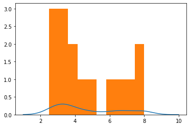

```python
plt.plot(xs,density(xs))
plt.hist(water_data)
```

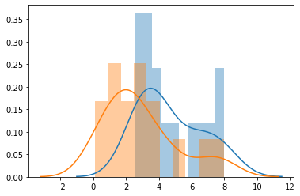

```python
sbn.distplot(water_data, bins = 10, label= "Water")
sbn.distplot(bev_data, bins= 10, label= "Beverage")
```

### Approximations

**Median**

The median is the middle value and thus in the density plot it is the value which will split the curve into two equal area plots.

For the above plots the median for the water plot (the one in blue) would be somewhere on a bit right from the top peak in the curve, something about 4.

Similary, for the median of the beverage plot (the one in orange) would be somewhere around the intersection of the plots, near 3.

**Mean**

The idea of mean is where the middle point of the value lie considering the weights of the values in the curve, hence the long trail towards the end would mean taking the value of x * y at that point.

The mean for the water plot would hence be located right of the median as the median doesn't consider weight of the values and mean does, hence the second curve would prove to shift the mean towards the right.

Similarly, for the beverage curve would suggest the mean towards the right of the median but unlike the water plot it would be closer to median as the values on the right are less weight in the density plot.

1. A car company wants to predict how much fuel different cars will use based on their masses. They took a sample of cars, drove each car 100km, and measured how much fuel was used in each case (in litres). Visualize the data using scatterplot and also find co-relation between the 2 variables (eg. Positive//Negative, Linear/ Non-linear co-relation) The data is summarized in the table below. (Use a reasonable scale on both axes and put the explanatory variable on the x-axis.)

| Fuel used (L) | 3.6 | 6.7 | 9.8 | 11.2 | 14.7 |
| --- | --- | --- | --- | --- | --- |
| Mass (metric tons) | 0.45 | 0.91 | 1.36 | 1.81 | 2.27 |

```python
fuel_data = [3.6, 6.7, 9.8,11.2, 14.7]
mass_data = [0.45, 0.91, 1.36, 1.81, 2.27]
```

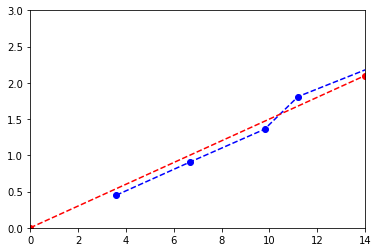

```python
plt.xlim(0, 14)
plt.ylim(0, 3)
plt.plot(fuel_data, mass_data, "--ob", [0, 14], [0, 2.1], "--or")
```

### Inference

From the above it is clear that the dotted line has a positve slope, hence the *positive correlation* between **Fuel** and **Mass**.

The Line connecting the points is almost doesn't vary in the slope hence the a *Linear Relation* between can be assumed too.

1. The data below represents the number of chairs in each class of a government high school. Create a box plot and swarm plot (add jitter) and find the number of data points that are outliers.

35, 54, 60, 65, 66, 67, 69, 70, 72, 73, 75, 76, 54, 25, 15, 60, 65, 66, 67, 69, 70, 72, 130, 73, 75, 76

[output not shown]

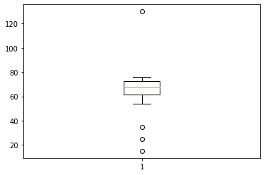

```python
data = [35, 54, 60, 65, 66, 67, 69, 70, 72, 73, 75, 76, 54, 25, 15, 60, 65, 66, 67, 69, 70, 72, 130, 73, 75, 76]
plt.boxplot(data)
```

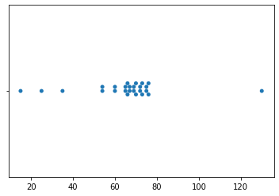

```python
sbn.swarmplot(data)
```

### Outlier Count

The outliers that are present in the above box plot and swarm plots count to 4.

1. Generate random numbers from the following distribution and visualize the data using violin plot. (i) Standard-Normal distribution. (ii) Log-Normal distribution.

```
{'bodies': [<matplotlib.collections.PolyCollection at 0x7f67192cead0>],
 'cmaxes': <matplotlib.collections.LineCollection at 0x7f67192ce990>,
 'cmins': <matplotlib.collections.LineCollection at 0x7f67192cee90>,
 'cbars': <matplotlib.collections.LineCollection at 0x7f67192ce7d0>}
```

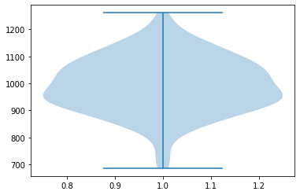

```python
data_norm = np.random.normal(1000, 100, 200)
plt.violinplot(data_norm)
```

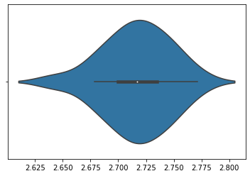

```python
data_lognorm = np.random.lognormal(1, .01, 20)
sbn.violinplot(data_lognorm)
```

1. An Advertisement agency develops new ads for various clients (like Jewellery shops, Textile shops). The Agency wants to assess their performance, for which they want to know the number of ads they developed in each quarter for different shop category. Help them to visualize data using radar/spider charts.

| Shop Category | Quarter 1 | Quarter 2 | Quarter 3 | Quarter 4 |
| --- | --- | --- | --- | --- |
| Textile | 10 | 6 | 8 | 13 |
| Jewellery | 5 | 5 | 2 | 4 |
| Cleaning Essentials | 15 | 20 | 16 | 15 |
| Cosmetics | 14 | 10 | 21 | 11 |

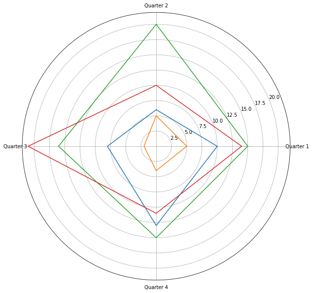

```python
data = {
    "Textile": [10, 6, 8, 13],
    "Jewellery": [5, 5, 2, 4],
    "Cleaning Essentials": [15, 20, 16, 15],
    "Cosmetics": [14, 10, 21, 11]
}
categories = ["Quarter 1", "Quarter 2", "Quarter 3", "Quarter 4"]
for key in data:
    data[key] += data[key][:1]
an = [0, math.pi / 2, math.pi, math.pi * 1.5, 2 * math.pi]
fig = plt.figure(figsize = (10, 10))
ax = plt.subplot(111, polar= True)
plt.xticks(an, categories)
plt.polar(an, data["Textile"])
plt.polar(an, data["Jewellery"])
plt.polar(an, data["Cleaning Essentials"])
plt.polar(an, data["Cosmetics"])
```

1. An organization wants to calculate the % of time they spent on each process for their product development. Visualize the data using funnel chart with the data given below.

| Product Development steps | Time spent (in hours) |
| --- | --- |
| Requirement Elicitation | 50 |
| Requirement Analysis | 110 |
| Software Development | 250 |
| Debugging & Testing | 180 |
| Others | 70 |

```python
data = dict(
    steps = [
    "Requirement Elicitation",
    "Requirement Analysis",
    "Software Development",
    "Debugging & Testing",
    "Others"
],
time = [
    50,
    110,
    250,
    180,
    70
])
```

```python
zipped_lists = zip(data['time'], data['steps'])
sorted_zipped_lists = sorted(zipped_lists, reverse= True)
data['steps'] = [element for _, element in sorted_zipped_lists]
data['time'] = sorted(data['time'], reverse= True)
px.funnel(data, x= "time", y= "steps")
```

[interactive chart not shown]

1. Let's say you are the new owner of a small ice-cream shop in a little village near the beach. You noticed that there was more business in the warmer months than the cooler months. Before you alter your purchasing pattern to match this trend, you want to be sure that the relationship is real. Help him to find the correlation between the data given.

| Temperature | Number of Customers |
| --- | --- |
| 98 | 15 |
| 87 | 12 |
| 90 | 10 |
| 85 | 10 |
| 95 | 16 |
| 75 | 7 |

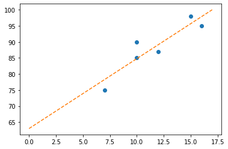

```python
temp_data = [98, 87, 90, 85, 95, 75]
cust_data = [15, 12, 10, 10, 16, 7]
# plt.xlim(0,20)
# plt.ylim(0,100)
plt.plot(cust_data, temp_data, "o", [0, 17], [63, 100], '--')
```